# DM_Project_1

Abram Chan, Falomy Eugene, Yan Qi

10/28/2021

##Import libraries here:

```r
library(e1071)
library(tidyverse)
```

```r
library(ggplot2)
library(ggExtra)
library(gridExtra)
library(dplyr)
library(e1071)
library(pROC)
library(ROCit)
library(naivebayes)
library(psych)
library(caret)
library(regclass)
library(rpart)
library(rpart.plot)
library(splitstackshape)
library(caTools)
#ignore the warning below or unshow the warnings by run this chunk twice
```

##Major reason choosing R: EDA for this assignment requires a high level of customization, particularly for outliers’ detection(Q5) and imputation(Q7).

##Import ‘census’ dataset

```r
raw <- read.csv("C:/Users/Abram/Desktop/AFF/SMU/2021Fall/ModB/DM/ASSIGNMENT_1/adult.csv")

#preview dataset
summary(raw)
```

```
##       X39         State.gov             X77516         Bachelors
##  Min.   :17.00   Length:32560       Min.   :  12285   Length:32560
##  1st Qu.:28.00   Class :character   1st Qu.: 117832   Class :character
##  Median :37.00   Mode  :character   Median : 178363   Mode  :character
##  Mean   :38.58                      Mean   : 189782
##  3rd Qu.:48.00                      3rd Qu.: 237055
##  Max.   :90.00                      Max.   :1484705
##       X13        Never.married      Adm.clerical       Not.in.family
##  Min.   : 1.00   Length:32560       Length:32560       Length:32560
##  1st Qu.: 9.00   Class :character   Class :character   Class :character
##  Median :10.00   Mode  :character   Mode  :character   Mode  :character
##  Mean   :10.08
##  3rd Qu.:12.00
##  Max.   :16.00
##     White               Male               X2174             X0
##  Length:32560       Length:32560       Min.   :    0   Min.   :   0.00
##  Class :character   Class :character   1st Qu.:    0   1st Qu.:   0.00
##  Mode  :character   Mode  :character   Median :    0   Median :   0.00
##                                        Mean   : 1078   Mean   :  87.31
##                                        3rd Qu.:    0   3rd Qu.:   0.00
##                                        Max.   :99999   Max.   :4356.00
##       X40        United.States         X..50K
##  Min.   : 1.00   Length:32560       Length:32560
##  1st Qu.:40.00   Class :character   Class :character
##  Median :40.00   Mode  :character   Mode  :character
##  Mean   :40.44
##  3rd Qu.:45.00
##  Max.   :99.00
```

```r
str(raw)
```

```
## 'data.frame':    32560 obs. of  15 variables:
##  $ X39          : int  50 38 53 28 37 49 52 31 42 37 ...
##  $ State.gov    : chr  " Self-emp-not-inc" " Private" " Private" " Private" ...
##  $ X77516       : int  83311 215646 234721 338409 284582 160187 209642 45781 159449 280464 ...
##  $ Bachelors    : chr  " Bachelors" " HS-grad" " 11th" " Bachelors" ...
##  $ X13          : int  13 9 7 13 14 5 9 14 13 10 ...
##  $ Never.married: chr  " Married-civ-spouse" " Divorced" " Married-civ-spouse" " Married-civ-spouse" ...
##  $ Adm.clerical : chr  " Exec-managerial" " Handlers-cleaners" " Handlers-cleaners" " Prof-specialty" ...
##  $ Not.in.family: chr  " Husband" " Not-in-family" " Husband" " Wife" ...
##  $ White        : chr  " White" " White" " Black" " Black" ...
##  $ Male         : chr  " Male" " Male" " Male" " Female" ...
##  $ X2174        : int  0 0 0 0 0 0 0 14084 5178 0 ...
##  $ X0           : int  0 0 0 0 0 0 0 0 0 0 ...
##  $ X40          : int  13 40 40 40 40 16 45 50 40 80 ...
##  $ United.States: chr  " United-States" " United-States" " United-States" " Cuba" ...
##  $ X..50K       : chr  " <=50K" " <=50K" " <=50K" " <=50K" ...
```

```r
head(raw)
```

```
##   X39         State.gov X77516  Bachelors X13          Never.married
## 1  50  Self-emp-not-inc  83311  Bachelors  13     Married-civ-spouse
## 2  38           Private 215646    HS-grad   9               Divorced
## 3  53           Private 234721       11th   7     Married-civ-spouse
## 4  28           Private 338409  Bachelors  13     Married-civ-spouse
## 5  37           Private 284582    Masters  14     Married-civ-spouse
## 6  49           Private 160187        9th   5  Married-spouse-absent
##         Adm.clerical  Not.in.family  White    Male X2174 X0 X40  United.States
## 1    Exec-managerial        Husband  White    Male     0  0  13  United-States
## 2  Handlers-cleaners  Not-in-family  White    Male     0  0  40  United-States
## 3  Handlers-cleaners        Husband  Black    Male     0  0  40  United-States
## 4     Prof-specialty           Wife  Black  Female     0  0  40           Cuba
## 5    Exec-managerial           Wife  White  Female     0  0  40  United-States
## 6      Other-service  Not-in-family  Black  Female     0  0  16        Jamaica
##   X..50K
## 1  <=50K
## 2  <=50K
## 3  <=50K
## 4  <=50K
## 5  <=50K
## 6  <=50K
```

##Answer for the Q1: 32560 observations(rows) and 15 variables(columns)

##From the results above, we can tell that the existing dataset does not contains col names, thus, we want to ssign the col names here:

```r
names(raw)<-c('age','workclass','fnlwgt','education','education_num','marital_status','occupation','relationship','race','sex','capital_gain','capital_loss','hours_per_week','native_country', 'income')

head(raw)
```

```
##   age         workclass fnlwgt  education education_num         marital_status
## 1  50  Self-emp-not-inc  83311  Bachelors            13     Married-civ-spouse
## 2  38           Private 215646    HS-grad             9               Divorced
## 3  53           Private 234721       11th             7     Married-civ-spouse
## 4  28           Private 338409  Bachelors            13     Married-civ-spouse
## 5  37           Private 284582    Masters            14     Married-civ-spouse
## 6  49           Private 160187        9th             5  Married-spouse-absent
##           occupation   relationship   race     sex capital_gain capital_loss
## 1    Exec-managerial        Husband  White    Male            0            0
## 2  Handlers-cleaners  Not-in-family  White    Male            0            0
## 3  Handlers-cleaners        Husband  Black    Male            0            0
## 4     Prof-specialty           Wife  Black  Female            0            0
## 5    Exec-managerial           Wife  White  Female            0            0
## 6      Other-service  Not-in-family  Black  Female            0            0
##   hours_per_week native_country income
## 1             13  United-States  <=50K
## 2             40  United-States  <=50K
## 3             40  United-States  <=50K
## 4             40           Cuba  <=50K
## 5             40  United-States  <=50K
## 6             16        Jamaica  <=50K
```

##Since the variable fnlwgt is an observation multiplier, we want to modify the dataset here:

```r
#We want to rescale the dataset by 10k rather than directly multiplying, since if then, the we would have over 6 billions obs
raw$fnlwgt <- sapply(raw$fnlwgt, function(x) x/10000)
raw <- expandRows(raw, "fnlwgt")

str(raw)
```

```
## 'data.frame':    601547 obs. of  14 variables:
##  $ age           : int  50 50 50 50 50 50 50 50 38 38 ...
##  $ workclass     : chr  " Self-emp-not-inc" " Self-emp-not-inc" " Self-emp-not-inc" " Self-emp-not-inc" ...
##  $ education     : chr  " Bachelors" " Bachelors" " Bachelors" " Bachelors" ...
##  $ education_num : int  13 13 13 13 13 13 13 13 9 9 ...
##  $ marital_status: chr  " Married-civ-spouse" " Married-civ-spouse" " Married-civ-spouse" " Married-civ-spouse" ...
##  $ occupation    : chr  " Exec-managerial" " Exec-managerial" " Exec-managerial" " Exec-managerial" ...
##  $ relationship  : chr  " Husband" " Husband" " Husband" " Husband" ...
##  $ race          : chr  " White" " White" " White" " White" ...
##  $ sex           : chr  " Male" " Male" " Male" " Male" ...
##  $ capital_gain  : int  0 0 0 0 0 0 0 0 0 0 ...
##  $ capital_loss  : int  0 0 0 0 0 0 0 0 0 0 ...
##  $ hours_per_week: int  13 13 13 13 13 13 13 13 40 40 ...
##  $ native_country: chr  " United-States" " United-States" " United-States" " United-States" ...
##  $ income        : chr  " <=50K" " <=50K" " <=50K" " <=50K" ...
```

##After the multiplication, the obs number is 601547, we droped the multiplication col fnlwgt, thus, we have 14 cols here.

##Return a table with variable names & types

```r
table_name <- names(raw)
table_ty <- data.frame(matrix(nrow=1, ncol=1))

colnames(table_ty) <- c('type')
for (i in table_name) {
  name <- typeof(raw[,i])
  table_ty <- table_ty %>%
    add_row(type = name)
}

table_ty <- table_ty[-1,]
type <- data.frame(table_name,table_ty)
names(type) <- c('variable', 'type')

#Table
type
```

```
##          variable      type
## 1             age   integer
## 2       workclass character
## 3       education character
## 4   education_num   integer
## 5  marital_status character
## 6      occupation character
## 7    relationship character
## 8            race character
## 9             sex character
## 10   capital_gain   integer
## 11   capital_loss   integer
## 12 hours_per_week   integer
## 13 native_country character
## 14         income character
```

##Answer for the Q2: Tables of variables with their types can be shown above.

##Return the table of statistics for specific cols

```r
var <- c("age", "education_num", "capital_gain", "capital_loss", "hours_per_week")

calstats <- function(x) {
  miss <- sum(is.na(x))
  min <- round(min(x,na.rm=TRUE), 2)
  max <- round(max(x,na.rm = TRUE), 2)
  median <- round(median(x, na.rm = TRUE), 2)
  mean <- round(mean(x, na.rm = TRUE), 2)
  sd <- round(sd(x,na.rm = TRUE), 2)
  skew <- round(skewness(x,na.rm=TRUE), 2)
  kurt <- round(kurtosis(x,na.rm=TRUE), 2)
  result <- data.frame(miss, min, max, median, mean, sd, skew, kurt)

}

rslt <- data.frame(matrix(nrow=0, ncol=8))
colnames(rslt) <- c('miss', 'min', 'max', 'median', 'mean', 'sd', 'skew', 'kurt')

for (i in var) {
  result <- calstats(raw[,i])
  rslt <- rslt %>%
    add_row(result)
}

rownames(rslt) <- c("age", "education_num", "capital_gain", "capital_loss", "hours_per_week")

#table
rslt
```

```
##                miss min   max median    mean      sd  skew   kurt
## age               0  17    90     36   37.98   13.46  0.60  -0.12
## education_num     0   1    16     10   10.02    2.61 -0.36   0.66
## capital_gain      0   0 99999      0 1079.53 7436.39 11.91 153.19
## capital_loss      0   0  4356      0   84.95  396.63  4.64  20.80
## hours_per_week    0   1    99     40   40.31   12.09  0.20   2.99
```

```r
length(unique(raw$education_num))
```

```
## [1] 16
```

##Answer for the Q3: since for the col ‘education_num’, there’re only 16 distinct values, based on the fact that the col is about the years of education for each observation, 16 could be defined as ‘few distinct value’, thus, we want to convert this col into categorical. We will change this col to character first for the convenience of graph and to factor right before the models building part. ##Answer for the Q4: table of statistics can be shown above ‘rslt’.

##Convert datatype for col ‘education_num’

```r
raw$education_num <- as.character(raw$education_num)
summary(raw$education_num)
```

```
##    Length     Class      Mode
##    601547 character character
```

##Identify the numeric cols for which outlier detection is desired(col ‘education_num’ was originally numeric, we changed it into character in Q3) ##col ‘fnlwgt’ is numeric, however, given its attribute is multiplier, we do not want to include this col in the outlier and model part.

```r
#str(raw)
out <- c("age", "capital_gain", "capital_loss", "hours_per_week")

str(raw)
```

```
## 'data.frame':    601547 obs. of  14 variables:
##  $ age           : int  50 50 50 50 50 50 50 50 38 38 ...
##  $ workclass     : chr  " Self-emp-not-inc" " Self-emp-not-inc" " Self-emp-not-inc" " Self-emp-not-inc" ...
##  $ education     : chr  " Bachelors" " Bachelors" " Bachelors" " Bachelors" ...
##  $ education_num : chr  "13" "13" "13" "13" ...
##  $ marital_status: chr  " Married-civ-spouse" " Married-civ-spouse" " Married-civ-spouse" " Married-civ-spouse" ...
##  $ occupation    : chr  " Exec-managerial" " Exec-managerial" " Exec-managerial" " Exec-managerial" ...
##  $ relationship  : chr  " Husband" " Husband" " Husband" " Husband" ...
##  $ race          : chr  " White" " White" " White" " White" ...
##  $ sex           : chr  " Male" " Male" " Male" " Male" ...
##  $ capital_gain  : int  0 0 0 0 0 0 0 0 0 0 ...
##  $ capital_loss  : int  0 0 0 0 0 0 0 0 0 0 ...
##  $ hours_per_week: int  13 13 13 13 13 13 13 13 40 40 ...
##  $ native_country: chr  " United-States" " United-States" " United-States" " United-States" ...
##  $ income        : chr  " <=50K" " <=50K" " <=50K" " <=50K" ...
```

##Identify outliers using ‘boxplot.stats’

```r
var_1 <- c("age", "capital_gain", "capital_loss", "hours_per_week")
outliers <- c()
for (i in var_1) {
  outliers <- c(outliers,length(boxplot.stats(raw[,i])$out))
}

#summary(raw)

data.frame(var_1,outliers)
```

```
##            var_1 outliers
## 1            age     2596
## 2   capital_gain    49612
## 3   capital_loss    27415
## 4 hours_per_week   162095
```

##Answer for the Q5: Specific outliers counts can be shown at the table above

##Answers for the Q6 and Q7: see below steps

##Imputation for outliers(Be adivesd, assignment requirements pointed out for this step, specific presentation and introduction for the imputations are needed)

##We want to direct impute value for col ‘hours_per_week’ since there’re two ranges of outliers(set them to missing first may cause issues assigning values, detailed explanation seen below steps)

##We found out there should be a collinearity between col ‘education’ and ‘education-num’, thus, we intend to use ‘education’ instead of ‘education_num’ in the model. We do not impute values for the missings of col ‘education_num’

##‘Capital-gain’ and ‘Capital_loss’: we decide not include these two cols since they have too many zero-values

##Imputation for outliers

```r
#For hours_per_week, since the outliers detected by the 'boxplot.stats' contains over 162095 records, given the 601547 observations that the original dataset provides, the outliers detected occupies more than 27% of the original volume. Thus we want to manually replace the outliers, details see below:

#The outliers range is between[1,17] & [79,99], these numbers are somehow not extinct in real working scenarios, however, through boxplot we can say that these outliers presented a flat distribution compared to the box itsself, which will do harm to the models we are about to build, thus, we replaced outliers in [1,17] with the average of values in range [1,17] and [79,99] with the values average in range [79,99].

#unique(boxplot.stats(raw$hours_per_week)$out)

hpwo_c<-boxplot.stats(raw$hours_per_week)$out

raw$hours_per_week[raw$hours_per_week > 78] <- round(mean(Filter(function(x) any(x > 78), hpwo_c)))
raw$hours_per_week[raw$hours_per_week < 18] <- round(mean(Filter(function(x) any(x < 18), hpwo_c)))

summary(raw$hours_per_week)
```

```
##    Min. 1st Qu.  Median    Mean 3rd Qu.    Max.
##   11.00   40.00   40.00   40.29   45.00   87.00
```

##Return the table for the count of distince values for char vars

```r
data_type <- data.frame(unlist(sapply(raw,class)))
colnames(data_type)[1] <- "Variable Type"

cha <- c()
for (i in rownames(data_type)) {
  if (data_type[i,] == "character") {
    cha <- c(cha, i)}
  else {cha}
}

cnt <- c()
for (i in cha) {
  new_cnt <- length(unique(raw[,i]))
  cnt <- c(cnt, new_cnt)
}

all_char <- data.frame(var = cha, cnt_uni = cnt)

all_char
```

```
##               var cnt_uni
## 1       workclass       9
## 2       education      16
## 3   education_num      16
## 4  marital_status       7
## 5      occupation      15
## 6    relationship       6
## 7            race       5
## 8             sex       2
## 9  native_country      42
## 10         income       2
```

##Plot histogram for each of the numeric variables.

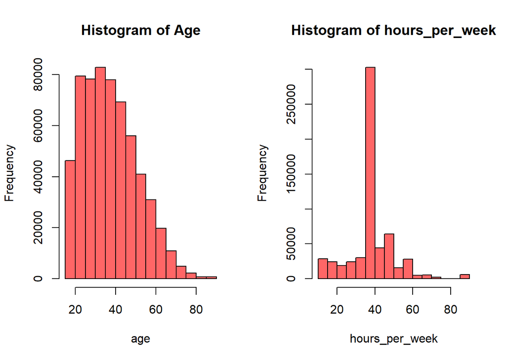

```r
par(mfrow=c(1,2))

hist(raw$age, main="Histogram of Age", xlab="age", col = "#FF6666")
#hist(raw$fnlwgt, main="Histogram of fnlwgt", xlab="fnlwgt", col = "#FF6666")
#hist(raw$education_num,  main="Histogram of education_num", xlab="education_num")
#hist(raw$capital_gain, main="Histogram of capital_gain", xlab="capital_gain")
#hist(raw$capital_loss, main="Histogram of capital_loss", xlab="capital_loss", col = "#FF6666")
hist(raw$hours_per_week, main="Histogram of hours_per_week", xlab="hours_per_week", col = "#FF6666")
```

```r
#No sweat for the graph size here, 4 in 1 graph was only intended for the test run.
#If you want to see the graph bigger, feel free to run each one of them by highlighting the specific line
#OR print out in console to change to any size you want
```

##Answer for the Q8: graph seen above

##Bar chart for each of the categorical variables

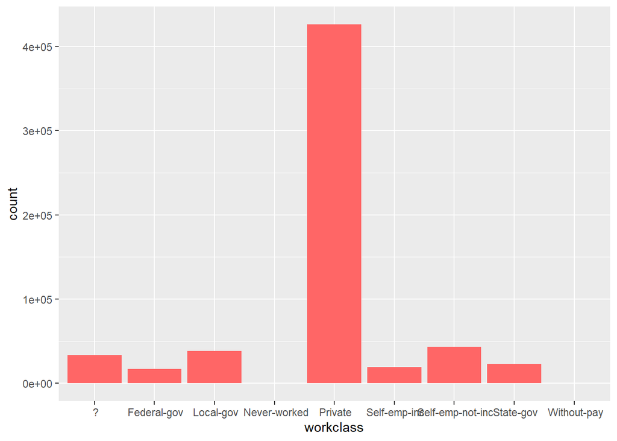

```r
ggplot(raw, aes(x = workclass)) + geom_bar(fill = "#FF6666")
```

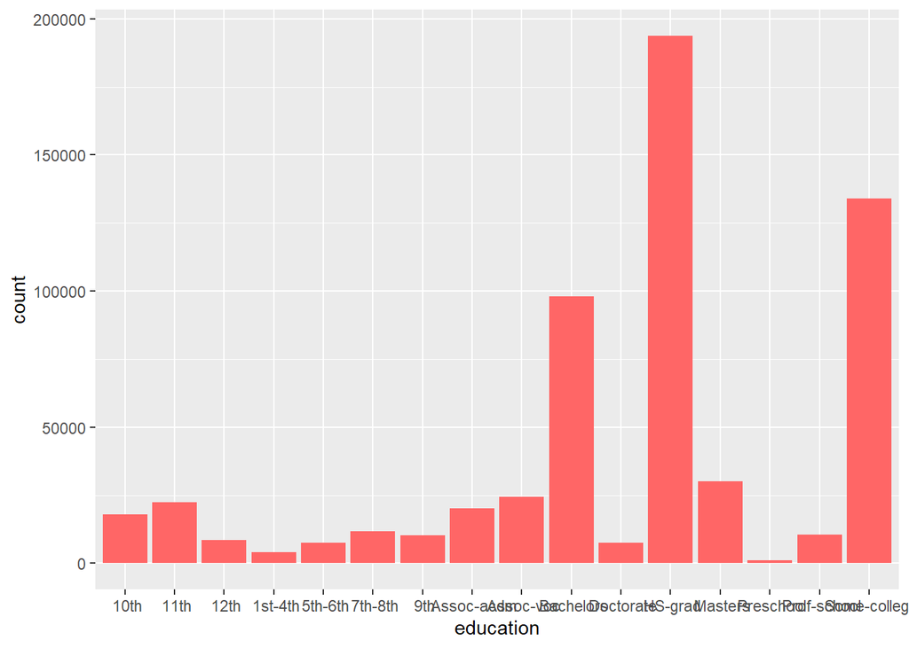

```r
ggplot(raw, aes(x = education)) + geom_bar(fill = "#FF6666")
```

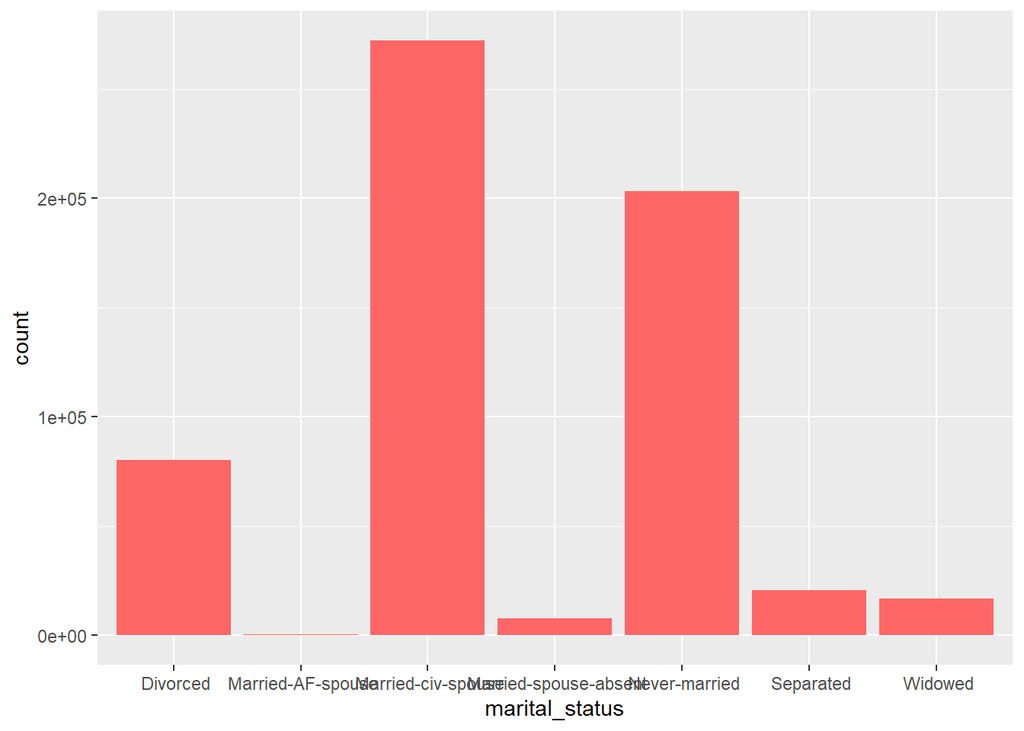

```r
ggplot(raw, aes(x = marital_status)) + geom_bar(fill = "#FF6666")
```

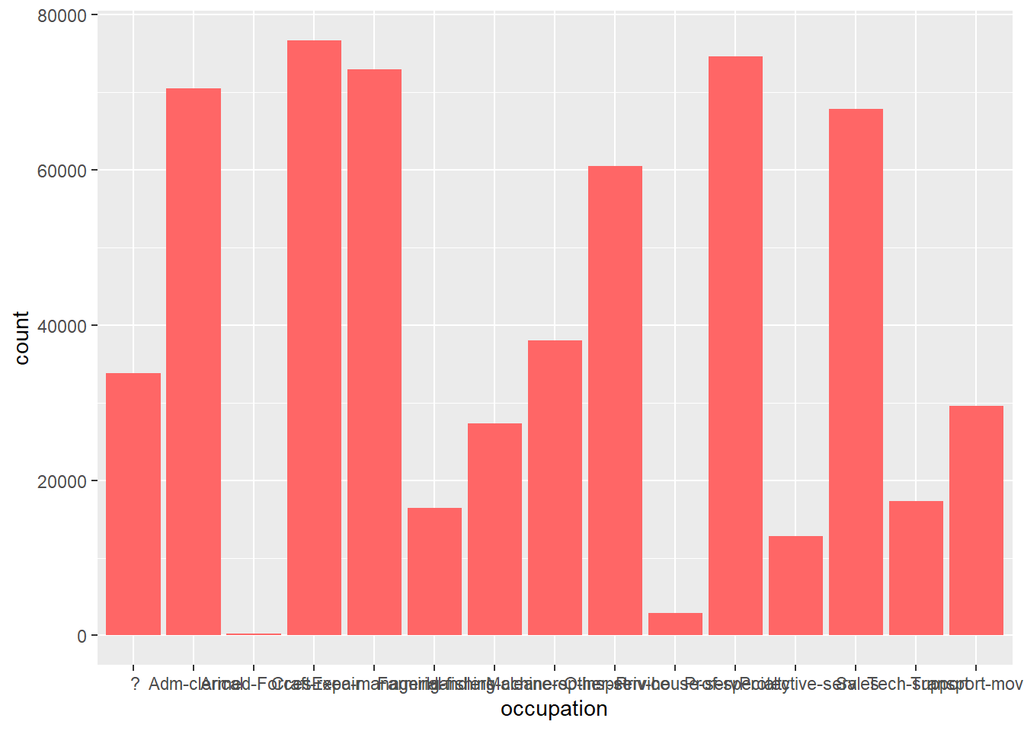

```r
ggplot(raw, aes(x = occupation)) + geom_bar(fill = "#FF6666")
```

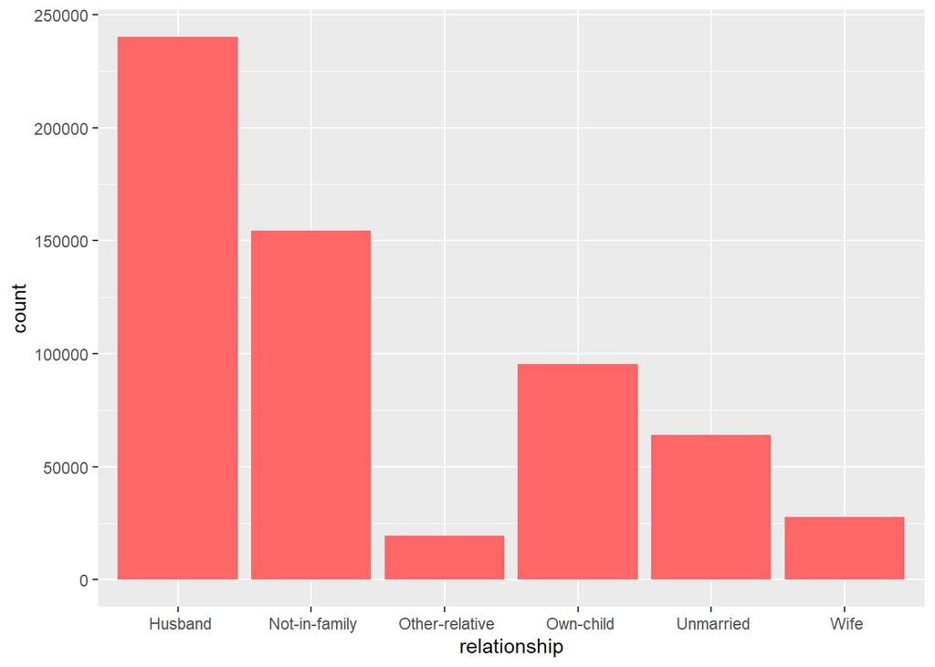

```r
ggplot(raw, aes(x = relationship)) + geom_bar(fill = "#FF6666")
```

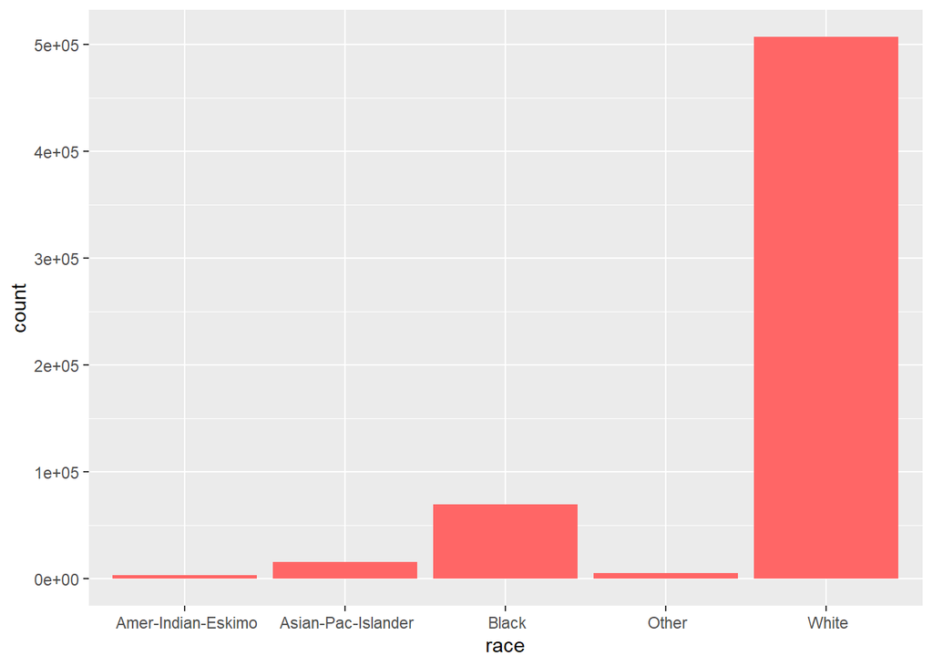

```r
ggplot(raw, aes(x = race)) + geom_bar(fill = "#FF6666")
```

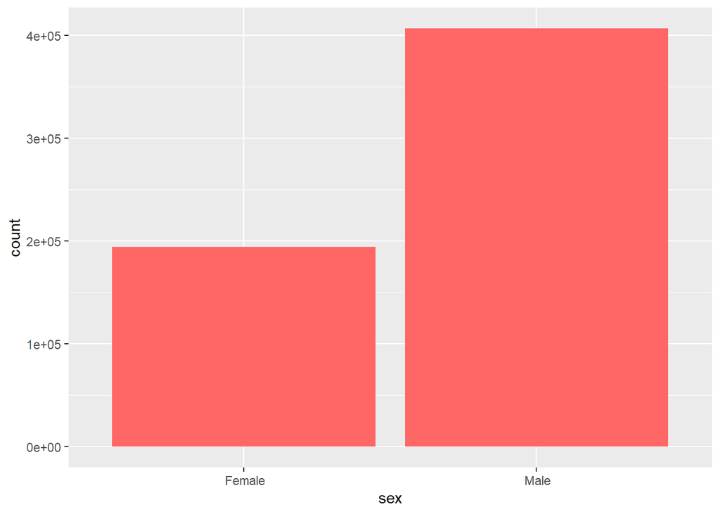

```r
ggplot(raw, aes(x = sex)) + geom_bar(fill = "#FF6666")
```

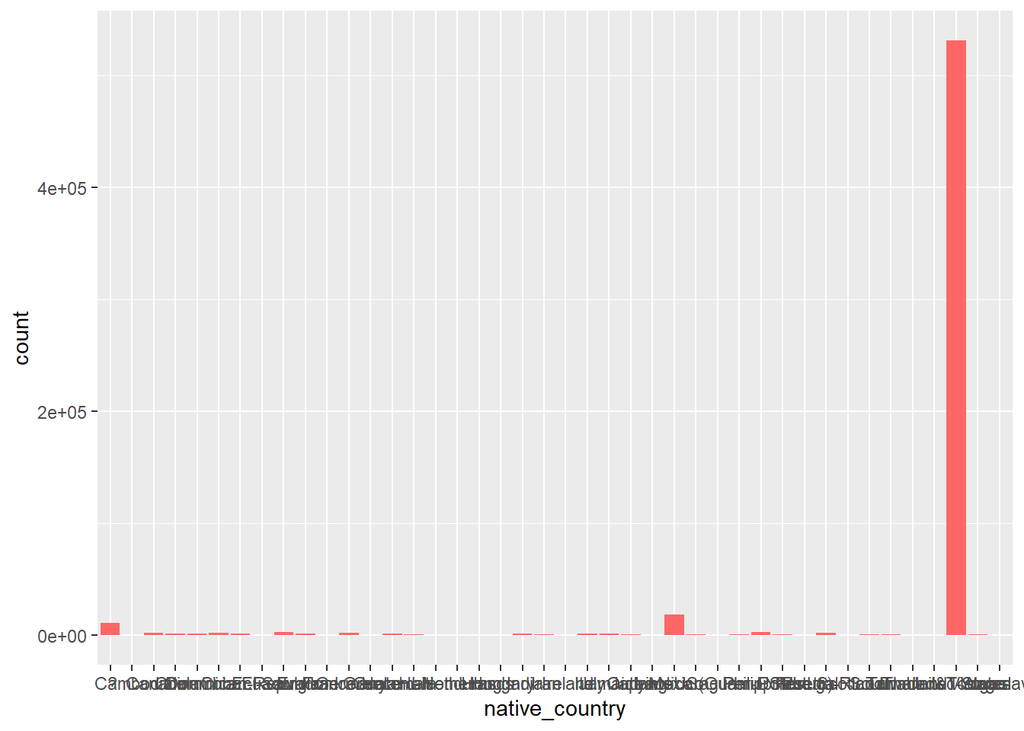

```r
ggplot(raw, aes(x = native_country)) + geom_bar(fill = "#FF6666")
```

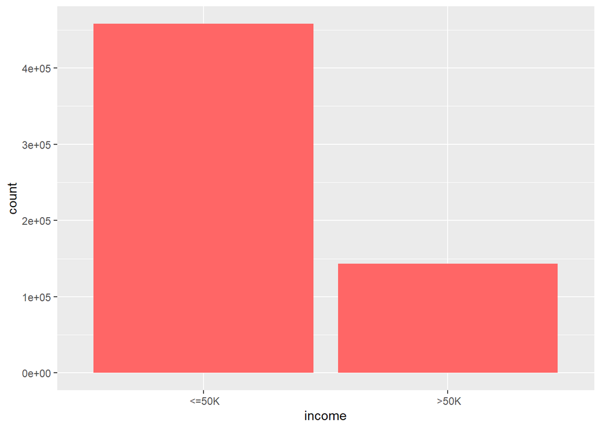

```r
ggplot(raw, aes(x = income)) + geom_bar(fill = "#FF6666")
```

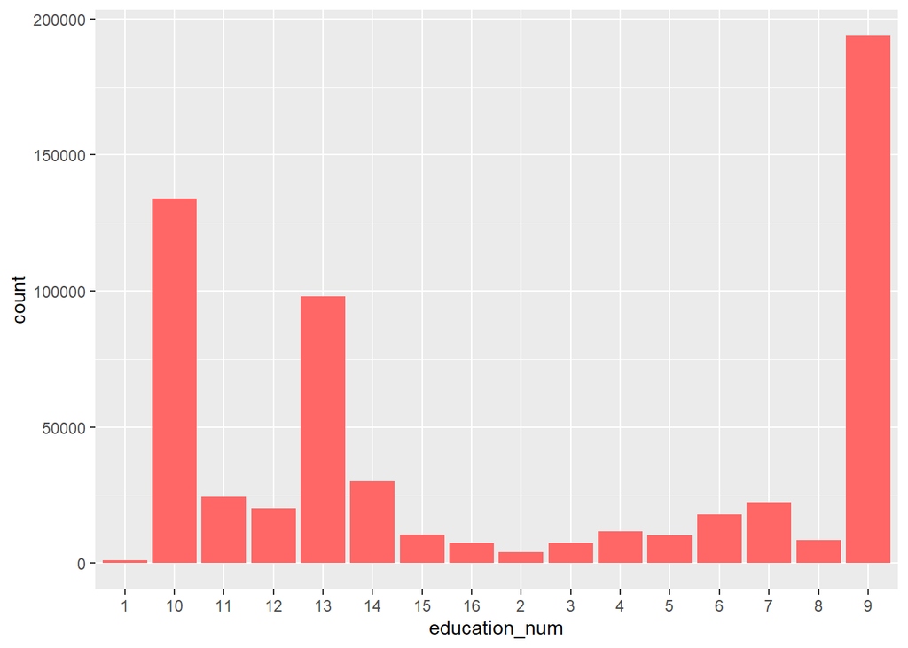

```r
ggplot(raw, aes(x = education_num)) + geom_bar(fill = "#FF6666")
```

```r
#No sweat for the graph size here, these graphs were only intended for the test run.
#If you want to see the graph bigger, feel free to run each one of them by highlighting the specific line and 'ctrl'+'Enter'
#OR print out in console to change to any size you ant
```

##Answer for the Q9: seen above

##Before we jump into the model part, we want to first modify our data types here:

```r
#Specific cols need to be changed to factor
raw$workclass <- as.factor(raw$workclass)
raw$education <- as.factor(raw$education)
raw$marital_status <- as.factor(raw$marital_status)
raw$occupation <- as.factor(raw$occupation)
raw$relationship <- as.factor(raw$relationship)
raw$race <- as.factor(raw$race)
raw$sex <- as.factor(raw$sex)
raw$native_country <- as.factor(raw$native_country)
raw$income <- as.factor(raw$income)
raw$education_num <- as.factor(raw$education_num)
```

##Output file(Optional)

```r
#write.csv(raw,"C:\\Users\\Abram\\Desktop\\raw.csv", row.names = FALSE)
```

##Create a new dataframe based on the specific cols we intended to input in our following process

```r
df <- raw[,c("age","workclass","education","marital_status","occupation","relationship","race","sex","hours_per_week","income")]
str(df)
```

```
## 'data.frame':    601547 obs. of  10 variables:
##  $ age           : int  50 50 50 50 50 50 50 50 38 38 ...
##  $ workclass     : Factor w/ 9 levels " ?"," Federal-gov",..: 7 7 7 7 7 7 7 7 5 5 ...
##  $ education     : Factor w/ 16 levels " 10th"," 11th",..: 10 10 10 10 10 10 10 10 12 12 ...
##  $ marital_status: Factor w/ 7 levels " Divorced"," Married-AF-spouse",..: 3 3 3 3 3 3 3 3 1 1 ...
##  $ occupation    : Factor w/ 15 levels " ?"," Adm-clerical",..: 5 5 5 5 5 5 5 5 7 7 ...
##  $ relationship  : Factor w/ 6 levels " Husband"," Not-in-family",..: 1 1 1 1 1 1 1 1 2 2 ...
##  $ race          : Factor w/ 5 levels " Amer-Indian-Eskimo",..: 5 5 5 5 5 5 5 5 5 5 ...
##  $ sex           : Factor w/ 2 levels " Female"," Male": 2 2 2 2 2 2 2 2 2 2 ...
##  $ hours_per_week: num  11 11 11 11 11 11 11 11 40 40 ...
##  $ income        : Factor w/ 2 levels " <=50K"," >50K": 1 1 1 1 1 1 1 1 1 1 ...
```

##Model01(Q10): Naïve Bayes Model

```r
#This step we partition the data into a training set (70%) and a validation set (30%)
set.seed(1234)
split <- sample.split(df, SplitRatio = 0.7)
train_data1 <- subset(df, split == "TRUE")
test_data1 <- subset(df, split == "FALSE")

str(train_data1)
```

```
## 'data.frame':    421083 obs. of  10 variables:
##  $ age           : int  50 50 50 50 50 50 38 38 38 38 ...
##  $ workclass     : Factor w/ 9 levels " ?"," Federal-gov",..: 7 7 7 7 7 7 5 5 5 5 ...
##  $ education     : Factor w/ 16 levels " 10th"," 11th",..: 10 10 10 10 10 10 12 12 12 12 ...
##  $ marital_status: Factor w/ 7 levels " Divorced"," Married-AF-spouse",..: 3 3 3 3 3 3 1 1 1 1 ...
##  $ occupation    : Factor w/ 15 levels " ?"," Adm-clerical",..: 5 5 5 5 5 5 7 7 7 7 ...
##  $ relationship  : Factor w/ 6 levels " Husband"," Not-in-family",..: 1 1 1 1 1 1 2 2 2 2 ...
##  $ race          : Factor w/ 5 levels " Amer-Indian-Eskimo",..: 5 5 5 5 5 5 5 5 5 5 ...
##  $ sex           : Factor w/ 2 levels " Female"," Male": 2 2 2 2 2 2 2 2 2 2 ...
##  $ hours_per_week: num  11 11 11 11 11 11 40 40 40 40 ...
##  $ income        : Factor w/ 2 levels " <=50K"," >50K": 1 1 1 1 1 1 1 1 1 1 ...
```

```r
#This step we use naive_bayes function in naivebayes library to train the model
model_nb <- naive_bayes(income ~ ., data = train_data1)
```

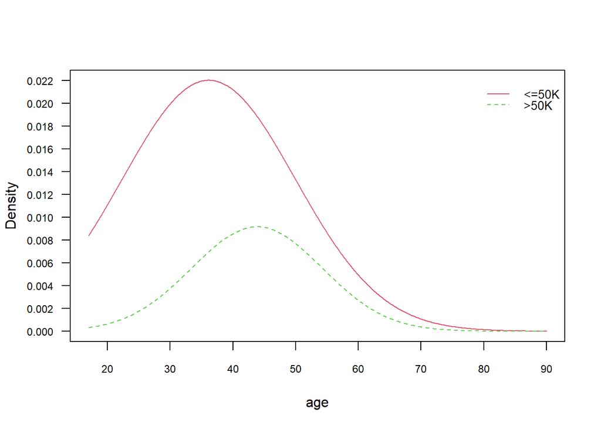

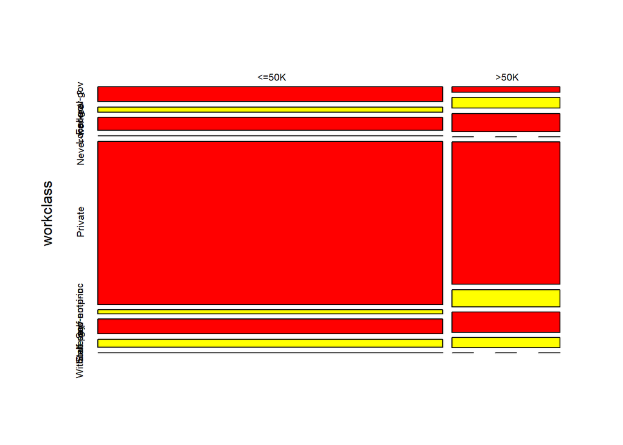

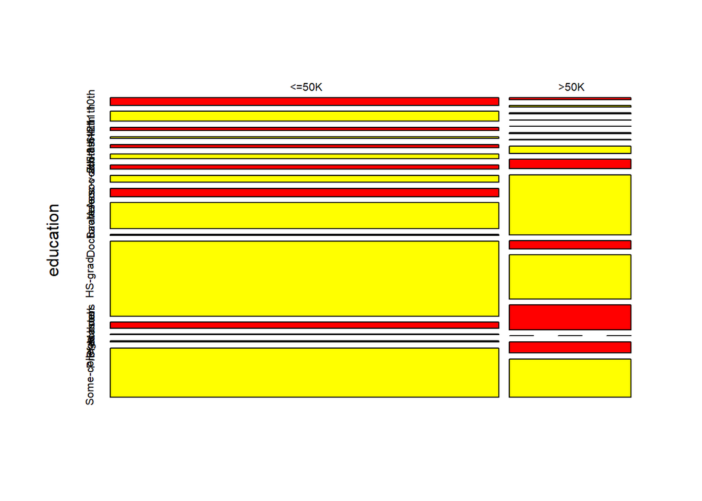

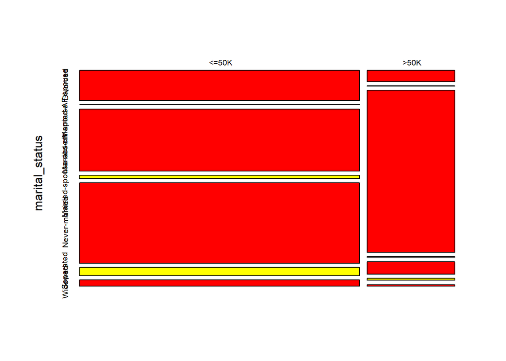

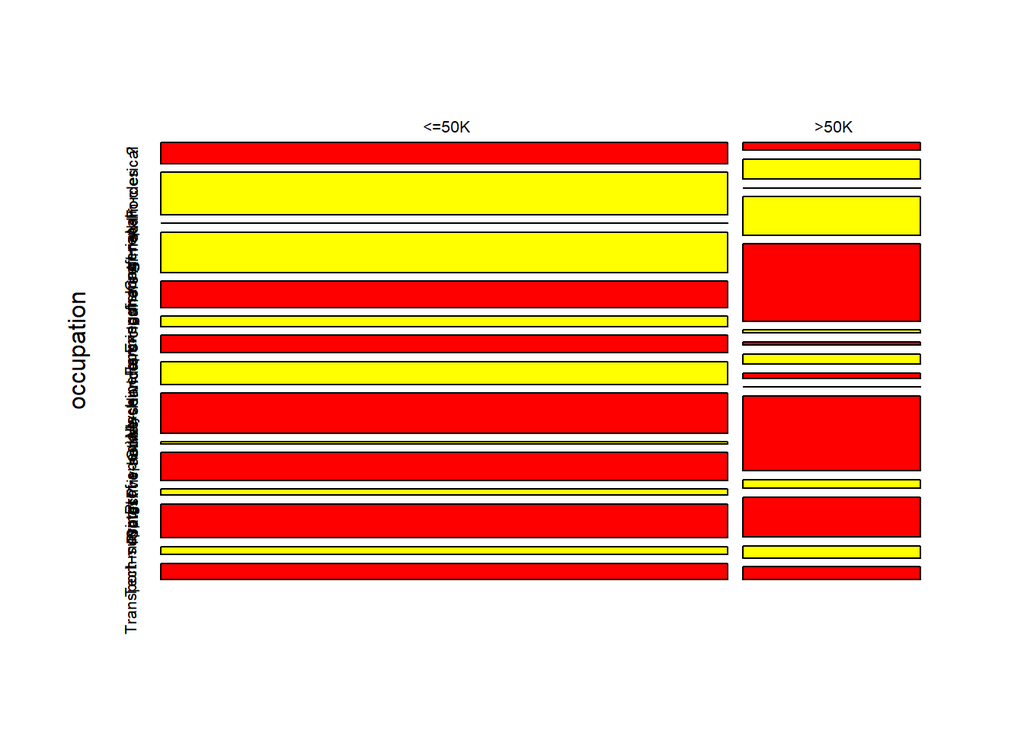

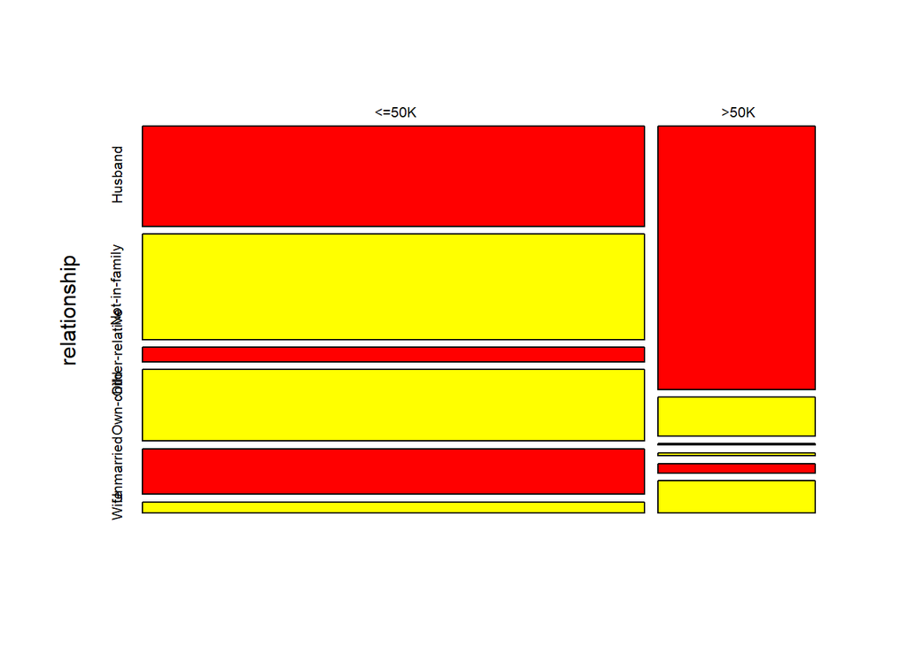

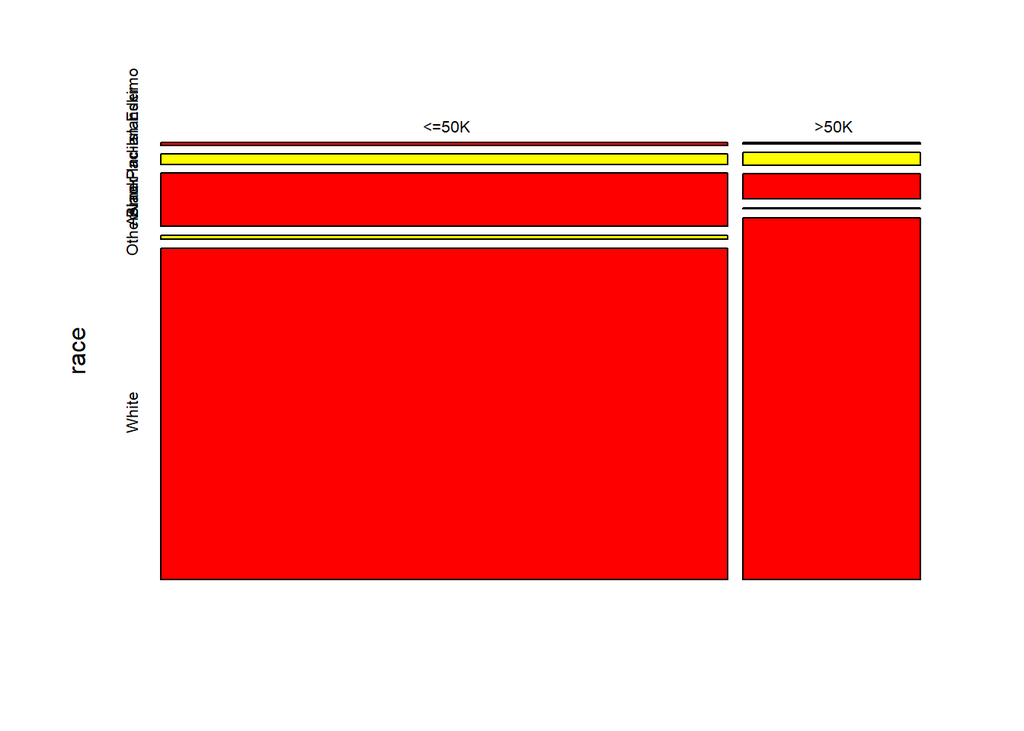

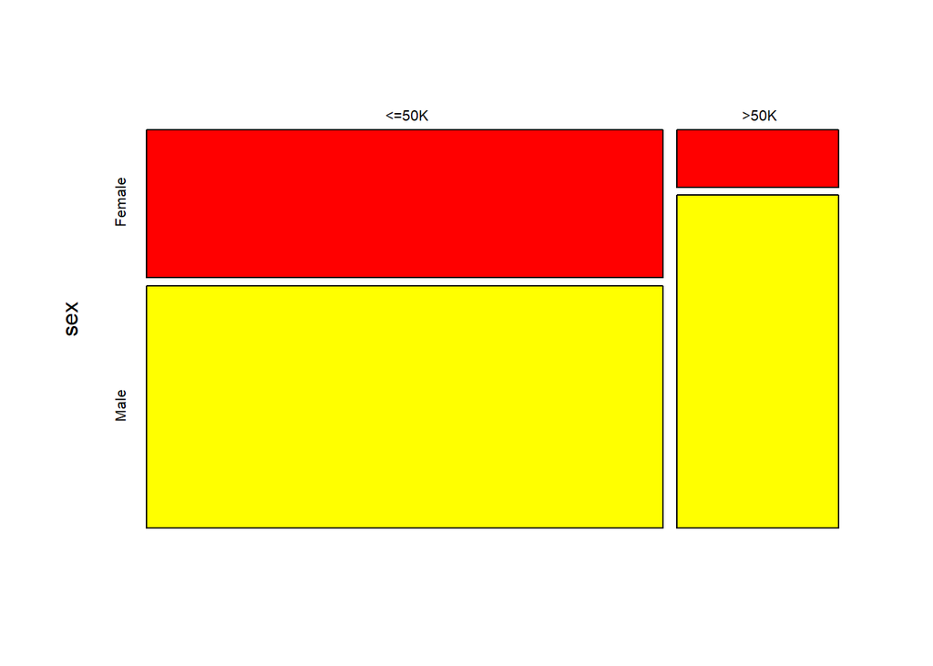

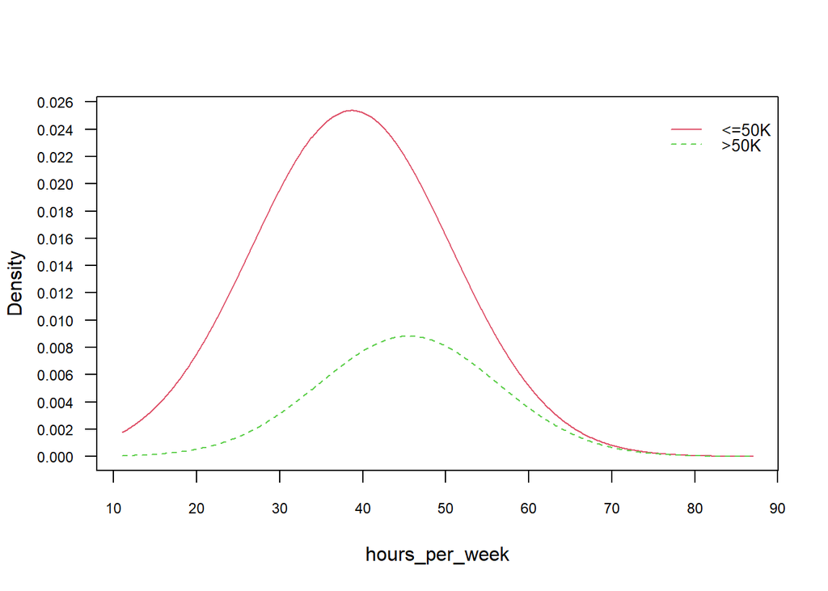

```r
plot(model_nb)
```